# Reproducible Research: Peer Assessment 1

Work by: Mike Rucker, Ph.D. Date: 7/16/2017

## Loading and preprocessing the data

1. Code (and libraries) for reading in the dataset and/or processing the data

```r
library(knitr)
library(plyr)
library(ggplot2)
library(scales)

activity <- read.csv("C:/temp/activity.csv", header=TRUE, sep=",")
```

## What is mean total number of steps taken per day?

2. Histogram of the total number of steps taken each day

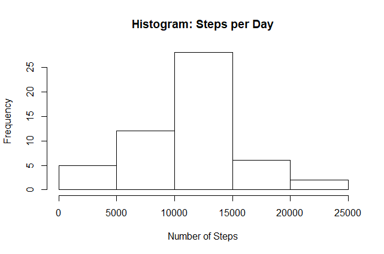

```r
hist(StepsPerDay, xlab = "Number of Steps", main = "Histogram: Steps per Day")
```

3. Mean and median number of steps taken each day

```r
MeanPerDay <- mean(StepsPerDay, na.rm = TRUE)
MedianPerDay <- median(StepsPerDay, na.rm = TRUE)
```

The mean per day is: `10766.1886792453` The median per day: `10765L`

## What is the average daily activity pattern?

4. Time series plot of the average number of steps taken

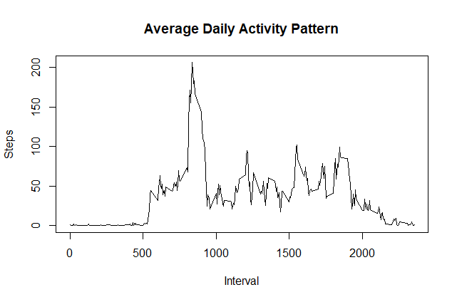

```r
StepsPerInterval <- tapply(activity$steps, activity$interval, mean, na.rm = TRUE)
plot(as.numeric(names(StepsPerInterval)),
     StepsPerInterval,
     xlab = "Interval",
     ylab = "Steps",
     main = "Average Daily Activity Pattern",
     type = "l")
```

```r
MaxInterval <- names(sort(StepsPerInterval, decreasing = TRUE)[1])
MaxSteps <- sort(StepsPerInterval, decreasing = TRUE)[1]
```

## Imputing missing values

```r
StepsPerInterval <- tapply(activity$steps, activity$interval, mean, na.rm = TRUE)
activity.split <- split(activity, activity$interval)
for(i in 1:length(activity.split)){
    activity.split[[i]]$steps[is.na(activity.split[[i]]$steps)] <- StepsPerInterval[i]
}
activity.imputed <- do.call("rbind", activity.split)
activity.imputed <- activity.imputed[order(activity.imputed$date) ,]
```

7. Histogram of the total number of steps taken each day after missing values are imputed

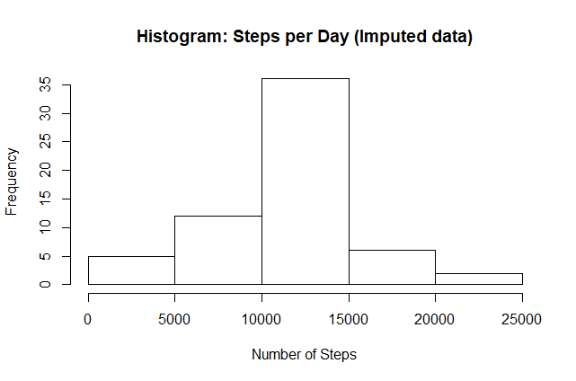

```r
StepsPerDay.imputed <- tapply(activity.imputed$steps, activity.imputed$date, sum)
hist(StepsPerDay.imputed, xlab = "Number of Steps", main = "Histogram: Steps per Day (Imputed data)")
```

8. Panel plot comparing the average number of steps taken per 5-minute interval across weekdays and weekends

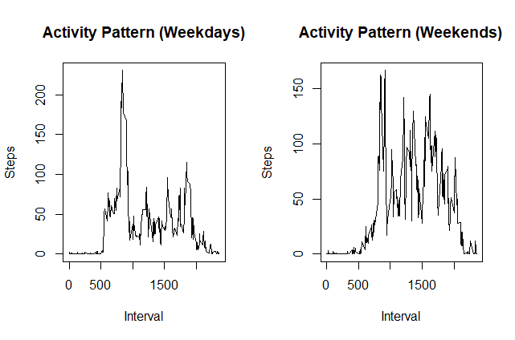

```r
MeanPerDay.imputed <- mean(StepsPerDay.imputed, na.rm = TRUE)
MedianPerDay.imputed <- median(StepsPerDay.imputed, na.rm = TRUE)
activity.imputed$day <- ifelse(weekdays(as.Date(activity.imputed$date)) == "Saturday" | weekdays(as.Date(activity.imputed$date)) == "Sunday", "weekend", "weekday")
StepsPerInterval.weekend <- tapply(activity.imputed[activity.imputed$day == "weekend" ,]$steps, activity.imputed[activity.imputed$day == "weekend" ,]$interval, mean, na.rm = TRUE)
StepsPerInterval.weekday <- tapply(activity.imputed[activity.imputed$day == "weekday" ,]$steps, activity.imputed[activity.imputed$day == "weekday" ,]$interval, mean, na.rm = TRUE)
par(mfrow=c(1,2))
plot(as.numeric(names(StepsPerInterval.weekday)),
     StepsPerInterval.weekday,
     xlab = "Interval",
     ylab = "Steps",
     main = "Activity Pattern (Weekdays)",
     type = "l")
plot(as.numeric(names(StepsPerInterval.weekend)),
     StepsPerInterval.weekend,
     xlab = "Interval",
     ylab = "Steps",
     main = "Activity Pattern (Weekends)",
     type = "l")
```

9. All of the R code needed to reproduce the results (numbers, plots, etc.) in the report